# Example

Laura Ospina-Rozo

2023-01-28

This is an example to generate RMarkdown documents, and some types of figures and analysis that can be produced with R.

# Set up

## Header

The first part of the RMarkdown code defines the properties of your web page. For example. `toc_depth: 5` means that there are 5 levels of subtitles displayed in the table of contents. `code_folding: hide` is to create buttons so that the reader can choose which code chunks they want to see.

## Packages

Always include a list of the packages used in the code and even better to include the versions. Note I have already installed all these packages. And the code is used only to “activate them”

```r
# Import and process spectral data
library(pavo)

# Plots
library(ggplot2)

# Tidy up
library(dplyr)
library(tidyr)

# To avoid running issues
library(here)

# To insert images
library(imager)
```

# Data wrangling

Use dplyr and tidyverse to arrange your data.

mutate(): to create new columns, for example one column multiplied by another.

group_by() and summary(): When you have multiple measurements of the same sample and you want only the mean and sd.

gather(): When you want to join two columns, one below the other.

spread(): when you want to separate one column into two according to groups.

merge(): to join two data frames that have one column in common.

# Spectral Data

## Big files

```r
# Import data
BeetD1<-getspec(
  where = here::here("Data/Spectra"), # location
  ext = "txt", # extension of the files
  lim = c(300, 700), # limits
  decimal = ".")

BeetD2<-getspec(
  where = here::here("Data/Spectra"), # location
  ext = "txt", # extension of the files
  lim = c(450, 700), # limits
  decimal = ".")
```

*warning! models with this data are not reliable since we did not get values below 340nm

```r
# Change the names of the columns
# first column, wavelength should always be "wl"
names(BeetD2)<-c("wl","EpiLamp","CalFren","AnoAure","AnoLaeG")
tail(BeetD2)
```

```
##      wl  EpiLamp  CalFren  AnoAure  AnoLaeG
## 246 695 8.376739 7.592521 28.42647 13.40084
## 247 696 9.830006 7.760218 28.81002 14.13870
## 248 697 9.594600 7.747265 29.15058 14.28130
## 249 698 9.415218 8.063718 29.69281 13.57783
## 250 699 9.057027 8.379373 30.48071 13.02919
## 251 700 8.025674 8.447276 30.24904 13.09019
```

```r
# Fixing data
BeetD1 <- BeetD1 %>%
  as.rspec() %>% # convert to an r spec file
  procspec(.,fixneg="zero") # Fix negatives
```

```
## The spectral data contain 160 NA's(s), which should be reviewed closely.
```

```
## wavelengths found in column 1
```

```
## The spectral data contain 134 negative value(s),
##  which may produce unexpected results if used in models.
## Consider using procspec() to correct them.
```

```
## processing options applied:
## Negative value correction: converted negative values to zero
```

```r
procspec(as.rspec(BeetD1),fixneg="zero")
```

```
## wavelengths found in column 1
## processing options applied:
## Negative value correction: converted negative values to zero
```

[output not shown]

[output cut: 789 more lines]

```r
BeetD2 <- BeetD2 %>%
  as.rspec() %>% # convert to an r spec file
  procspec(.,fixneg="zero") # Fix negatives
```

```
## wavelengths found in column 1
## processing options applied:
## Negative value correction: converted negative values to zero
```

```r
BeetD3 <- procspec(BeetD2,opt="smooth", span=0.1)
```

```
## processing options applied:
## smoothing spectra with a span of 0.1
```

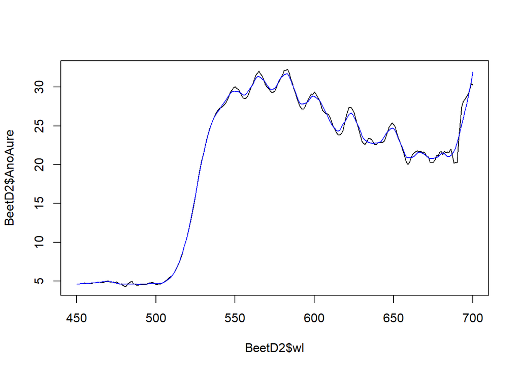

```r
plot(BeetD2$wl,BeetD2$AnoAure, type="l")
lines(BeetD3$wl,BeetD3$AnoAure,  col="blue")
```

note: a smoothing function can also be applied if needed with “opt” and the numbers “span”.

## Plots

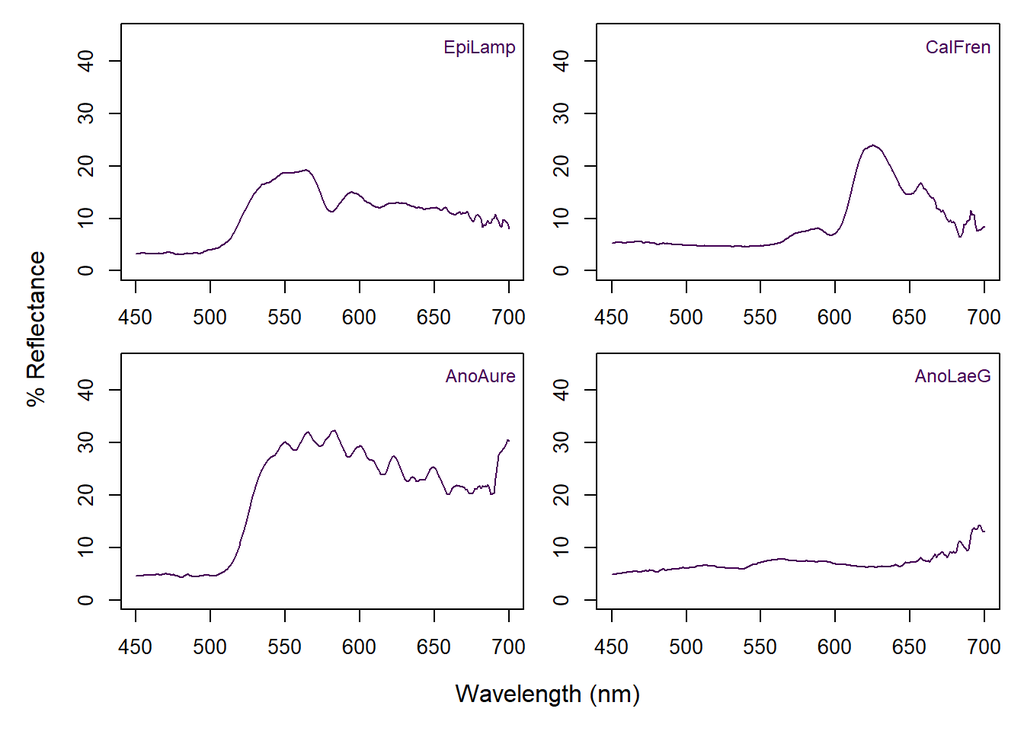

```r
# Use this to explore the data
explorespec(BeetD2)
```

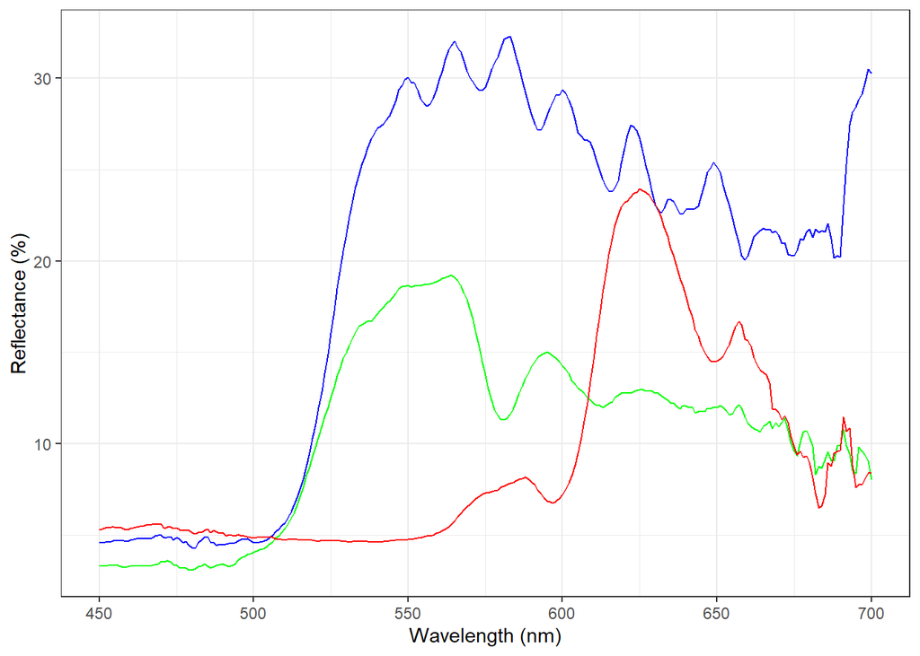

```r
# Use this to produce a plot
ggplot(data = BeetD2) +
  geom_line(aes(wl, AnoAure), col="blue")+
  theme_bw() +
  xlab("Wavelength (nm)")+
  ylab("Reflectance (%)")+
  geom_line(aes(wl, EpiLamp), col="green")+
  geom_line(aes(wl, CalFren), col="red")
```

```r
# An extra rearrange of data is needed to automatically include a legend.
```

## Spectral parameters  
Sometimes it is useful to identify the maximum wavelength (H1), or the area under the curve (B1). The function summary calculates these and some other parameters from the curves:

```r
summary(BeetD2)
```

```
##               B1        B2       B3 S1U S1V S1B       S1G       S1Y       S1R
## EpiLamp 2692.148 10.725691 19.23789  NA  NA  NA 0.5219604 0.4162918 0.4033994
## CalFren 2304.161  9.179923 23.96570  NA  NA  NA 0.2458262 0.3304249 0.6226480
## AnoAure 4954.581 19.739368 32.28009  NA  NA  NA 0.4897446 0.4395672 0.4583901
## AnoLaeG 1779.311  7.088890 14.28130  NA  NA  NA 0.3745308 0.3042617 0.4386669
##               S2        S3        S4        S5        S6         S7       S8
## EpiLamp 6.261382 0.5546608 1.5495333  662.7758 16.165422  0.7892275 1.507168
## CalFren 5.181604 0.6265253 2.0410167  729.5883 19.340547  0.6784743 2.106831
## AnoAure 7.526543 0.5716128 1.0273287 1410.2679 27.991255 -0.8114564 1.418042
## AnoLaeG 2.931345 0.2864403 0.8317676  155.3289  9.409373  0.8204424 1.327341
##                S9      S10  H1  H2  H3        H4  H5
## EpiLamp 0.5855392 2.335408 564 681 671 2.0574786 695
## CalFren 0.3717921 4.300077 625 693 663 0.8742164 690
## AnoAure 0.8477083 1.456795 583 687 527 1.6155947 690
## AnoLaeG 0.6278184 1.104039 697 667 688 0.4660598 690
```

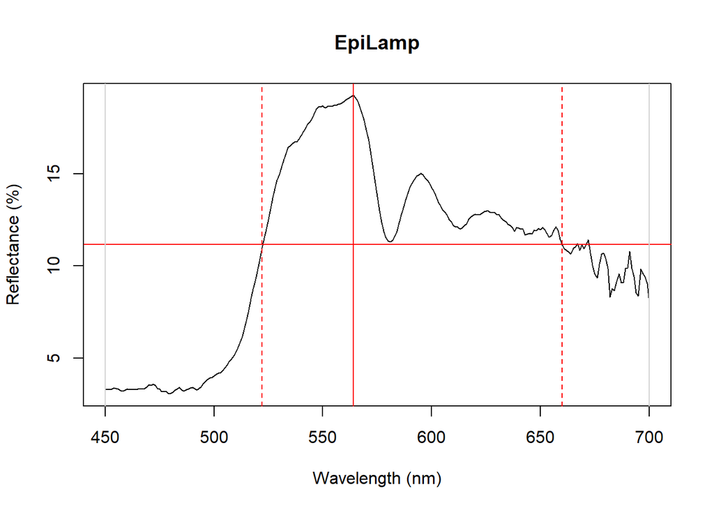

```
##        id       B3  H1 FWHM HWHM.l HWHM.r incl.min
## 1 EpiLamp 19.23789 564  138     42     96      Yes
```

```r
peakshape(BeetD2[,c(1,2)])
```

Note: We advocate for the use of the spectral location (i.e. The wavelength at which reflectance is half of the maximum, nm ) instead of the maximum wavelength (sometimes called Hue).

For more details on these parameters and formulae to automate their extraction see:https://lospinarozo.github.io/OpticalPropertiesNaturalMaterials_RCode2021/#Introduction and http://bitly.ws/ARIM

## Visual models One last cool feature!

With pavo it is possible to plot spectra in a colour space

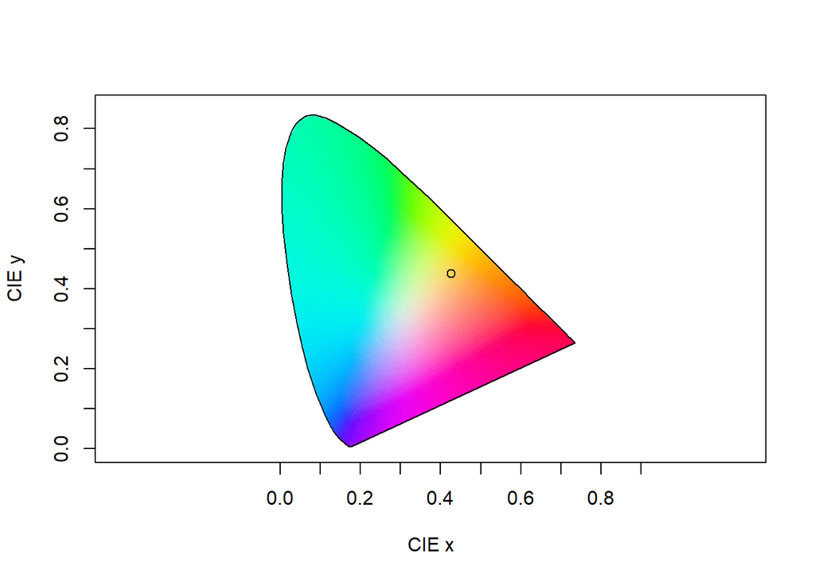

```r
vis.example <-
  vismodel(BeetD1[,c(1,2)], # Spectra
           visual="cie10", # Organism /  Human
           illum = 'D65', # Illumination
           vonkries = TRUE, # corrections
           relative = FALSE, achromatic = 'none') # others

vis.cols <- colspace(vis.example, space='ciexyz')

plot(vis.cols, pch=21)
```

However, the parameters of the model may differ for each project, so this step requires more analysis.

For more details about the models see: https://mran.microsoft.com/snapshot/2017-02-04/web/packages/pavo/vignettes/pavo-1_0.html

# Microscopy Data

This is the method I use to count layers.

## Tracing

This is the original image

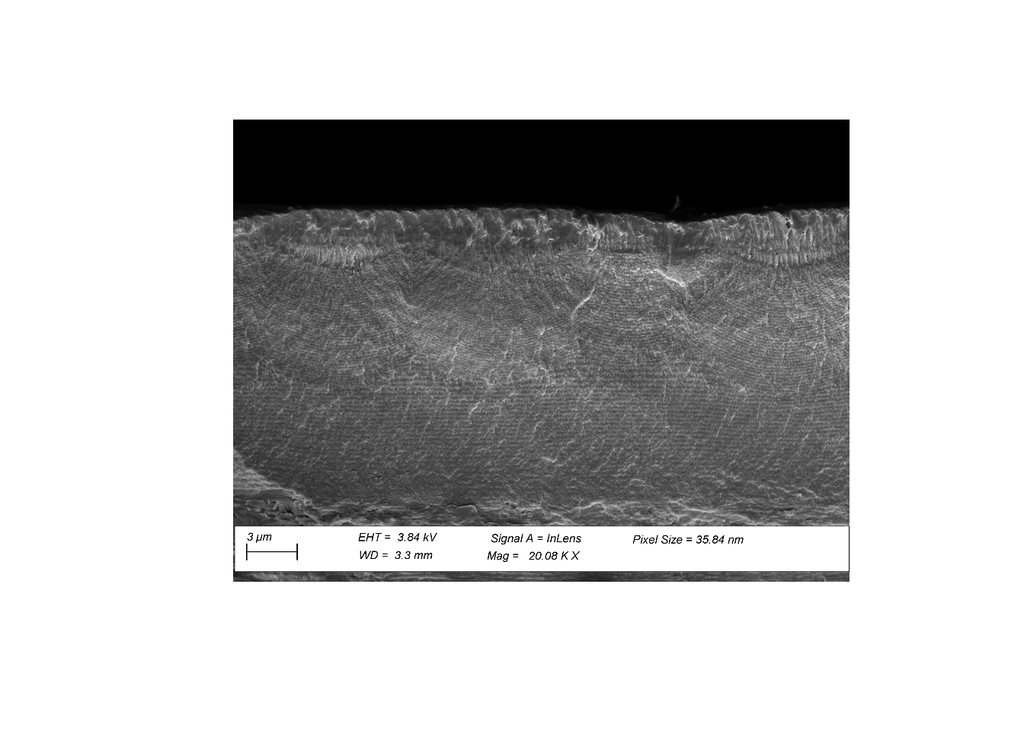

```r
im1<-load.image(here::here("Images/Lats.png"))
plot(im1, axes = FALSE)
```

I use a vector graphics software to trace the layers and produce this:

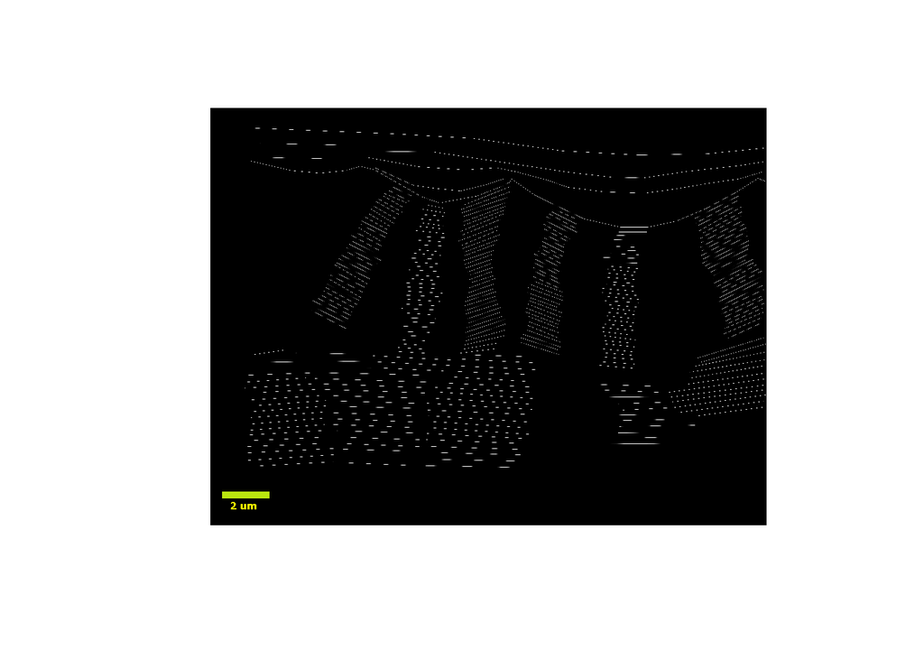

```r
im2<-load.image(here::here("Images/LatsLines.png"))
plot(im2, axes = FALSE)
```

And use plot profile in ImageJ to obtain the position of each line with reference to a starting point.

In this case, we will only consider one section of the png image. Import data.

```r
LatsP5L01<-read.csv(here::here("Data/Microscopy/A.laetus05LinesDataL1.csv"))
```

This is what ImageJ produces:

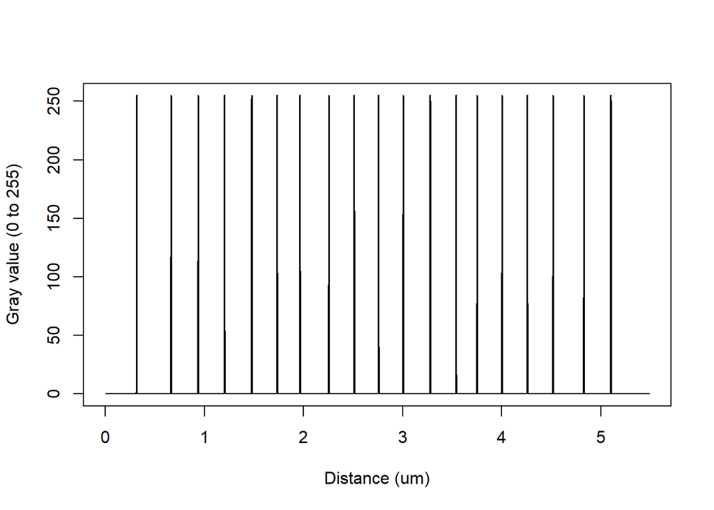

```r
plot(LatsP5L01$Distance_.µm.,LatsP5L01$Gray_Value, type="l", xlab="Distance (um)", ylab="Gray value (0 to 255)")
```

## Extract

To do that, define a function to calculate the distance:

*Not all the vector images are the same, so we need to use different parameters for the grey value and minimal distance between layers.

```r
#Define a function to extract the layers from the files
FindLayers2 <- function(Vector) {
  # filter values of distance with intensity > 245
  x<- filter(Vector, Gray_Value>245)
  # find difference between consecutive distance values
  xx <- diff(x$Distance_.µm.)[diff(x$Distance_.µm.)>0.0016] # adjust the  >xx distance for each spp:
  Lines <- xx
  Lines <- Lines*1000 # to nm since image measured in um
  return(Lines)
}
```

## Apply

[figure not shown]

```r
LatsInn1 <- FindLayers2(LatsP5L01)[-1] # remove the first one because that is an artifact

plot(seq(1:length(LatsInn1)), # a sequence of numbers
     LatsInn1,# vector with the distances
     pch=23,col="black", bg="violet", # shapes and colour
     ylab="Number of the layer",
     xlab= "Thickness (nm)"
     )
```

# Stats

For example, I want to compare if the distance between the dots is the same in two beetles of the same species, different colour. In the following montage, the red beetle is on the left and the green is on the right.

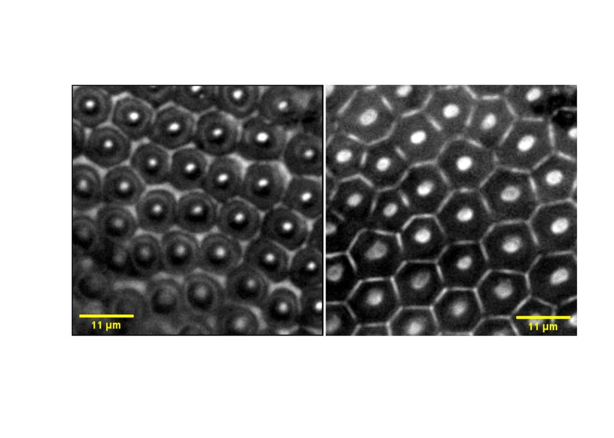

```r
im3<-load.image(here::here("Images/Montage.png"))
plot(im3, axes = FALSE)
```

I combine the plugin “Analyse particles” with “NND” in ImageJ to obtain the data on the distance between the dots.

```r
#Import
AnSmaR <- read.csv(here::here("Data/Others/NNDAnoSmaR1.csv"))
AnSmaG <- read.csv(here::here("Data/Others/NNDAnoSmaG1.csv"))

NND<- c(AnSmaR$C1, AnSmaG$C1)
Morph<- c(rep("Red",length(AnSmaR$C1)),
          rep("Green",length(AnSmaG$C1)))

Smaragdinus <- data.frame(NND,Morph)
```

Plot

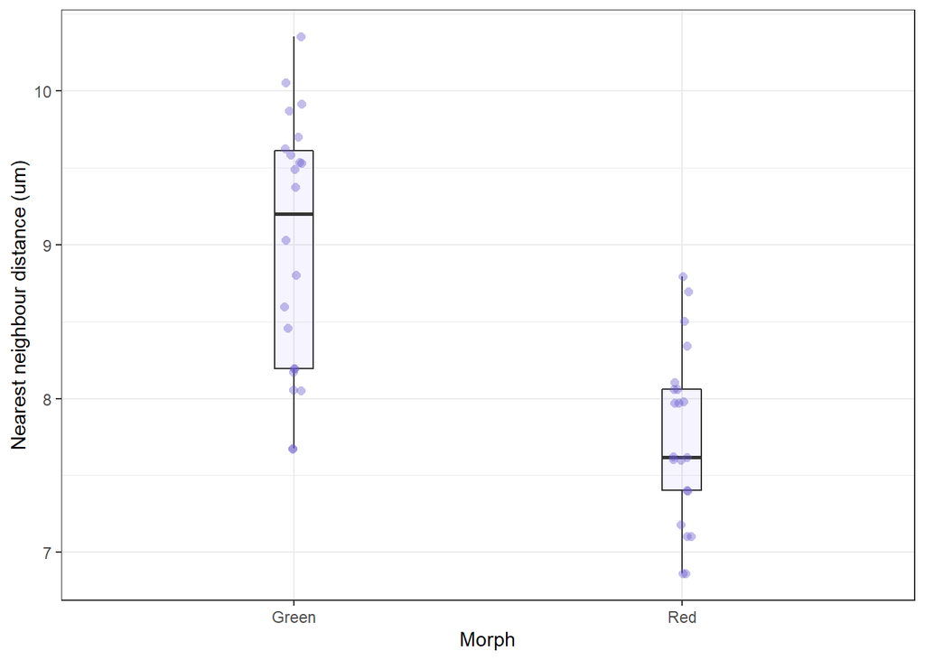

```r
ggplot(Smaragdinus, aes(Morph,NND))+
  geom_boxplot(bg="slateblue1", alpha=0.08, width=0.1)+
  geom_jitter(pch=16,col="slateblue3", alpha=0.4, cex=2,
              width = 0.025)+
  theme_bw()+
  ylab("Nearest neighbour distance (um)")
```

t-test

```r
t.test(NND~Morph)
```

```
##
##  Welch Two Sample t-test
##
## data:  NND by Morph
## t = 5.7531, df = 37.192, p-value = 1.333e-06
## alternative hypothesis: true difference in means between group Green and group Red is not equal to 0
## 95 percent confidence interval:
##  0.8052842 1.6806682
## sample estimates:
## mean in group Green   mean in group Red
##            8.997500            7.754524
```

Interpretation: The centers of the hexagons are more separated in the green morph than in the red morph.